**AI for Mechanical Engineering: Manufacturing**

By Dr. Bumsoo Park  
http://iailab.kaist.ac.kr/  
Industrial AI Lab at KAIST

# 1. Tool Wear Prediction

- Taylor's equation for tool wear:

$$VT^n = C, $$

- where
  - $V$: Cutting speed
  - $T$: Tool life
  - $n, C$: Empirical constants

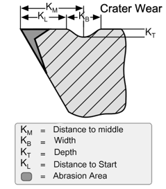

- A typical problem involves predicting/evaluating the remaining tool life, given conditions ($V, n, C$)

## 1.1 Prediction with Data

- What if we are only given data?

Download data [here](https://drive.google.com/file/d/1Vwp7taJjORX9KNXJ2r7cZQ4qSPCYCJpw/view?usp=sharing)

```python
import numpy as np
import pandas as pd
import matplotlib.pyplot as plt
import scipy
import sklearn
```

```python
from google.colab import drive
drive.mount('/content/drive')
```

```python
# Load the .npy file
data_loaded = np.load('/content/drive/MyDrive/AIME_Manufacturing/tool_wear_data.npy')

# Convert the numpy array to a DataFrame
df_loaded = pd.DataFrame(data_loaded, columns=['Cutting Speed (V)', 'Tool Life (T)'])
```

- Visualize loaded data

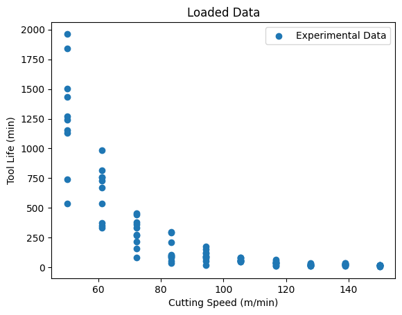

```python
# Original data
plt.scatter(df_loaded['Cutting Speed (V)'], df_loaded['Tool Life (T)'], label='Experimental Data')

plt.xlabel('Cutting Speed (m/min)')
plt.ylabel('Tool Life (min)')
plt.title('Loaded Data')
plt.legend()
plt.show()
```

### Option 1

- We know there is an exponential relationship between $V$ and $T$ (from $VT^n=C$)
- Using this information, we first linearize in log-log scale

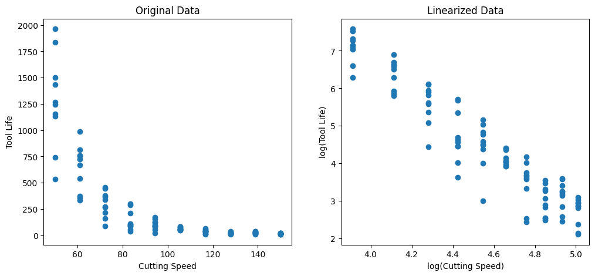

```python
df_loaded['log_V'] = np.log(df_loaded['Cutting Speed (V)'])
df_loaded['log_T'] = np.log(df_loaded['Tool Life (T)'])

# Plotting the original data and the linearized data
plt.figure(figsize=(12, 5))

# Original data
plt.subplot(1, 2, 1)
plt.scatter(df_loaded['Cutting Speed (V)'], df_loaded['Tool Life (T)'])
plt.xlabel('Cutting Speed')
plt.ylabel('Tool Life')
plt.title('Original Data')

# Linearized data
plt.subplot(1, 2, 2)
plt.scatter(df_loaded['log_V'], df_loaded['log_T'])
plt.xlabel('log(Cutting Speed)')
plt.ylabel('log(Tool Life)')
plt.title('Linearized Data')

plt.show()
```

- Next perform linear regression

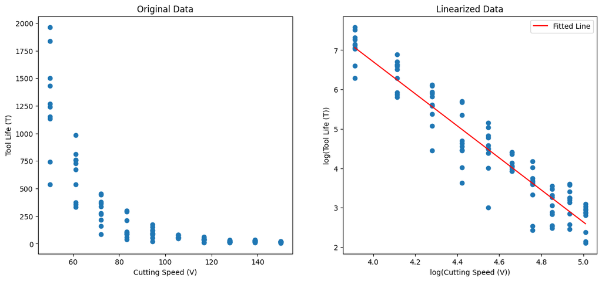

```python
# Perform linear regression on the log-transformed data
slope, intercept, r_value, p_value, std_err = scipy.stats.linregress(df_loaded['log_V'], df_loaded['log_T'])

# Calculate n and C from the slope and intercept
n_estimated = -1 / slope
C_estimated = np.exp(intercept * n_estimated)

# Plotting the original data and the linearized data
plt.figure(figsize=(14, 6))

# Original data
plt.subplot(1, 2, 1)
plt.scatter(df_loaded['Cutting Speed (V)'], df_loaded['Tool Life (T)'])
plt.xlabel('Cutting Speed (V)')
plt.ylabel('Tool Life (T)')
plt.title('Original Data')

# Linearized data
plt.subplot(1, 2, 2)
plt.scatter(df_loaded['log_V'], df_loaded['log_T'])
plt.plot(df_loaded['log_V'], slope * df_loaded['log_V'] + intercept, color='red', label='Fitted Line')
plt.xlabel('log(Cutting Speed (V))')
plt.ylabel('log(Tool Life (T))')
plt.title('Linearized Data')
plt.legend()

plt.show()
```

- Then transform back to linear space

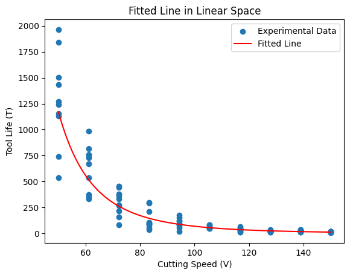

```
Estimated n: 0.24571963417534542
Estimated C: 283.6716060346621
```

```python
# Original data
plt.scatter(df_loaded['Cutting Speed (V)'], df_loaded['Tool Life (T)'], label='Experimental Data')

# Fitted line
cutting_speeds_fit = np.linspace(50, 150, 500)
tool_life_fit = (C_estimated / cutting_speeds_fit) ** (1 / n_estimated)
plt.plot(cutting_speeds_fit, tool_life_fit, color='red', label='Fitted Line')

plt.xlabel('Cutting Speed (V)')
plt.ylabel('Tool Life (T)')
plt.title('Fitted Line in Linear Space')
plt.legend()
plt.show()

print(f"Estimated n: {n_estimated}")
print(f"Estimated C: {C_estimated}")
```

### Option 2

- Use Scipy's optimize.curve_fit() function for optimization

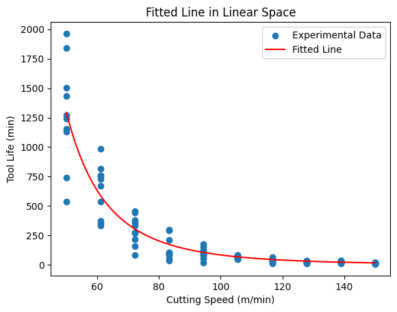

```
Estimated n: 0.2541470894413146
Estimated C: 308.90136308585073
```

```python
# Define Taylor's Tool Wear Equation for fitting
def taylors_equation(V, n, C):
    return (C / V) ** (1 / n)

# Initial guess for the parameters
initial_guess = [0.5, 100]

# Perform curve fitting: inputs(function, x, y, initial guess)
popt, pcov = scipy.optimize.curve_fit(taylors_equation, df_loaded['Cutting Speed (V)'],
                       df_loaded['Tool Life (T)'], p0=initial_guess)

# Extract the fitted parameters
n_fitted, C_fitted = popt

# Original data
plt.scatter(df_loaded['Cutting Speed (V)'], df_loaded['Tool Life (T)'], label='Experimental Data')

# Fitted line
cutting_speeds_fit = np.linspace(50, 150, 500)
tool_life_fit = (C_fitted / cutting_speeds_fit) ** (1 / n_fitted)
plt.plot(cutting_speeds_fit, tool_life_fit, color='red', label='Fitted Line')

plt.xlabel('Cutting Speed (m/min)')
plt.ylabel('Tool Life (min)')
plt.title('Fitted Line in Linear Space')
plt.legend()
plt.show()

print(f"Estimated n: {n_fitted}")
print(f"Estimated C: {C_fitted}")
```

# 2. Rotary Machinery Signal Analysis

- Assume we have time series vibration data from a rotary machine

(*data from CWRU dataset*: https://engineering.case.edu/bearingdatacenter/download-data-file)

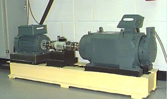

- 3 types of signals
  - Normal (Download normal data [here](https://drive.google.com/file/d/1VGzA-9W6joWizFI3p76p_5EqPSsmmEJ6/view?usp=sharing) )
  - Inner fault (Download inner fault data [here](https://drive.google.com/file/d/1ZJKrs5E5TIFAuoqIPiF221pSorczfeYM/view?usp=sharing))
  - Outer fault (Download outer fault data [here](https://drive.google.com/file/d/1mCPaUNi806kICVCkR4Fk1-Utvk_XG8R2/view?usp=sharing) )

```python
# Load the data from the .npy files
inner = np.load('/content/drive/MyDrive/AIME_Manufacturing/inner_split.npy')
inner = inner.reshape(1800, -1)
outer = np.load('/content/drive/MyDrive/AIME_Manufacturing/outer_split.npy')
outer = outer.reshape(1800, -1)
normal = np.load('/content/drive/MyDrive/AIME_Manufacturing/normal_split.npy')
normal = normal.reshape(1800, -1)

# Print the shapes or some basic information about the data to confirm it's loaded correctly
print("Inner Split Data Shape:", inner.shape)
print("Normal Split Data Shape:", normal.shape)
print("Outer Split Data Shape:", outer.shape)
```

```
Inner Split Data Shape: (1800, 527)
Normal Split Data Shape: (1800, 527)
Outer Split Data Shape: (1800, 527)
```

- Plot the signals

```
Normal data shape: (1800, 527)
Inner_fault data shape: (1800, 527)
Outer_fault data shape: (1800, 527)
```

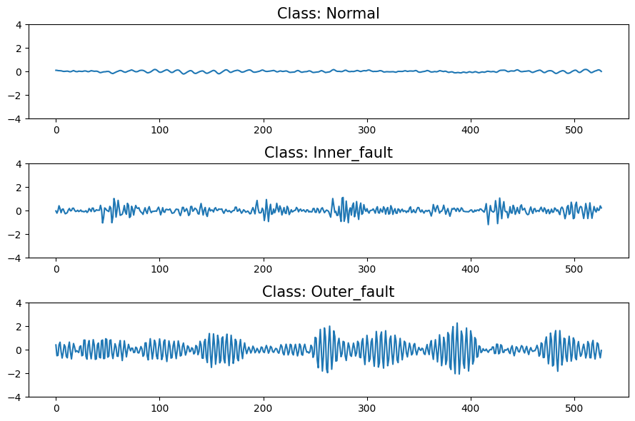

```python
classes = ['Normal', 'Inner_fault', 'Outer_fault']
data = [normal, inner, outer]

for state, name in zip(data, classes):
    print('{} data shape: {}'.format(name, state.shape))
plt.figure(figsize = (9, 6))
for i in range(3):
    plt.subplot(3,1,i+1)
    plt.title('Class: {}'.format(classes[i]), fontsize = 15)
    plt.plot(data[i][0])
    plt.ylim([-4,4])

plt.tight_layout()
plt.show()
```

## 2.1. Time Series Classification

- Recall SVM
  - Previously, the goal was to find the classification boundary(ies), given the features (data)
- For the data above, we need to determine features
- Types of features we can use for time series
  - Basic features (e.g. mean, max, min, standard deviation)
  - Derived features / features based on domain knowledge (e.g. Fourier transform, autocorreclation)
  - Advanced statistical features (e.g. Kurtosis, skewness)

### Basic Feature Selection

```python
from sklearn.svm import SVC
from sklearn.preprocessing import StandardScaler
from sklearn.model_selection import train_test_split
from sklearn.metrics import classification_report, accuracy_score
```

```python
all_data = np.vstack((normal, inner, outer))
all_data = all_data / np.max(all_data)
```

```python
def simple_features(trainX):
    n_data = len(trainX)
    reduced = np.zeros((n_data,2))
    for i in range(n_data):
        reduced[i,0] = np.median(trainX[i,:])
        reduced[i,1] = np.mean(trainX[i,:])

    return reduced

x = simple_features(all_data)
y = [0]*len(normal) + [1]*len(inner) + [2]*len(outer)
y = np.array(y)[:, np.newaxis]

scaler = StandardScaler()
train_X_scaled = scaler.fit_transform(x)
train_x, test_x, train_y, test_y = train_test_split(train_X_scaled,
                                                    y,
                                                    test_size = 0.2,
                                                    random_state = 42)
```

```
Accuracy: 0.7814814814814814
Classification Report:
              precision    recall  f1-score   support

           0       0.71      0.72      0.71       390
           1       0.76      0.73      0.74       341
           2       0.89      0.90      0.89       349

    accuracy                           0.78      1080
   macro avg       0.78      0.78      0.78      1080
weighted avg       0.78      0.78      0.78      1080
```

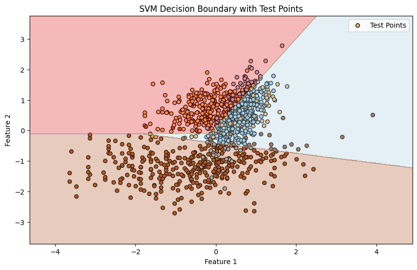

```python
import numpy as np
import matplotlib.pyplot as plt
from sklearn.svm import SVC
from sklearn.preprocessing import StandardScaler
from sklearn.model_selection import train_test_split
from sklearn.metrics import classification_report, accuracy_score


# Train SVM classifier
svm_classifier = SVC(kernel='linear', probability=True)  # Added probability for contour plotting
svm_classifier.fit(train_x, train_y.ravel())

# Predict on the test set
pred_y = svm_classifier.predict(test_x)

# Evaluate the classifier
print("Accuracy:", accuracy_score(test_y, pred_y))
print("Classification Report:")
print(classification_report(test_y, pred_y))

# Plotting decision boundaries
plt.figure(figsize=(10, 6))
plt.scatter(test_x[:, 0], test_x[:, 1], c=test_y.ravel(), s=30, cmap=plt.cm.Paired, edgecolors='k', label='Test Points')

# Plot the decision boundary. For that, we will assign a color to each
# point in the mesh [x_min, x_max]x[y_min, y_max].
x_min, x_max = test_x[:, 0].min() - 1, test_x[:, 0].max() + 1
y_min, y_max = test_x[:, 1].min() - 1, test_x[:, 1].max() + 1
xx, yy = np.meshgrid(np.arange(x_min, x_max, 0.02),
                     np.arange(y_min, y_max, 0.02))

Z = svm_classifier.predict(np.c_[xx.ravel(), yy.ravel()])
Z = Z.reshape(xx.shape)
plt.contourf(xx, yy, Z, alpha=0.3, cmap=plt.cm.Paired)

plt.xlabel('Feature 1')
plt.ylabel('Feature 2')
plt.title('SVM Decision Boundary with Test Points')
plt.legend()
plt.show()
```

### Feature Selection with Domain Knowledge (Frequency Domain)

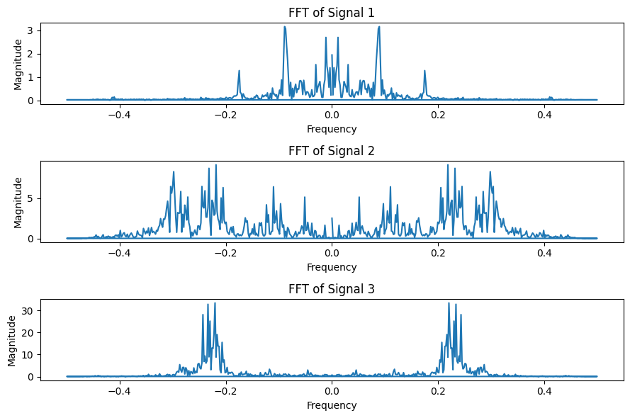

```python
# Example transformation (visualization)

signal1 = all_data[0,:]
signal2 = all_data[1800,:]
signal3 = all_data[3600,:]

# Compute FFT
fft_signal1 = np.fft.fft(signal1)
fft_signal2 = np.fft.fft(signal2)
fft_signal3 = np.fft.fft(signal3)

# Compute frequencies
freqs = np.fft.fftfreq(len(signal1))

# Plot the FFT results
fig, axs = plt.subplots(3, 1, figsize=(9, 6))

axs[0].plot(freqs, np.abs(fft_signal1))
axs[0].set_title('FFT of Signal 1')
axs[0].set_xlabel('Frequency')
axs[0].set_ylabel('Magnitude')

axs[1].plot(freqs, np.abs(fft_signal2))
axs[1].set_title('FFT of Signal 2')
axs[1].set_xlabel('Frequency')
axs[1].set_ylabel('Magnitude')

axs[2].plot(freqs, np.abs(fft_signal3))
axs[2].set_title('FFT of Signal 3')
axs[2].set_xlabel('Frequency')
axs[2].set_ylabel('Magnitude')

plt.tight_layout()
plt.show()
```

- We will try two options
  - Option 1: Dominant frequency and amplitude as features
  - Option 2: First and second dominant frequencies as features
- Option 1

```python
def frequency_features_opt1(trainX):
    n_data, n_samples = trainX.shape
    reduced = np.zeros((n_data,2))

    for i in range(n_data):
        # Perform FFT
        freq_signal = np.fft.fft(trainX[i,:])

        t = np.linspace(0, 1, n_samples, endpoint=False)

        frequencies = np.fft.fftfreq(n_samples, d=t[1]-t[0])

        # Find the index of the peak frequency
        peak_index = np.argmax(np.abs(freq_signal))

        # Most dominant frequency and its amplitude
        dominant_frequency = frequencies[peak_index]
        dominant_amplitude = np.abs(freq_signal)[peak_index]

        reduced[i,0] = dominant_frequency
        reduced[i,1] = dominant_amplitude

    return reduced

x = frequency_features_opt1(all_data)
y = [0]*len(normal) + [1]*len(inner) + [2]*len(outer)
y = np.array(y)[:, np.newaxis]

scaler = StandardScaler()
train_X_scaled = scaler.fit_transform(x)
train_x, test_x, train_y, test_y = train_test_split(train_X_scaled,
                                                    y,
                                                    test_size = 0.2,
                                                    random_state = 42)
```

```
Accuracy: 1.0
Classification Report:
              precision    recall  f1-score   support

           0       1.00      1.00      1.00       390
           1       1.00      1.00      1.00       341
           2       1.00      1.00      1.00       349

    accuracy                           1.00      1080
   macro avg       1.00      1.00      1.00      1080
weighted avg       1.00      1.00      1.00      1080
```

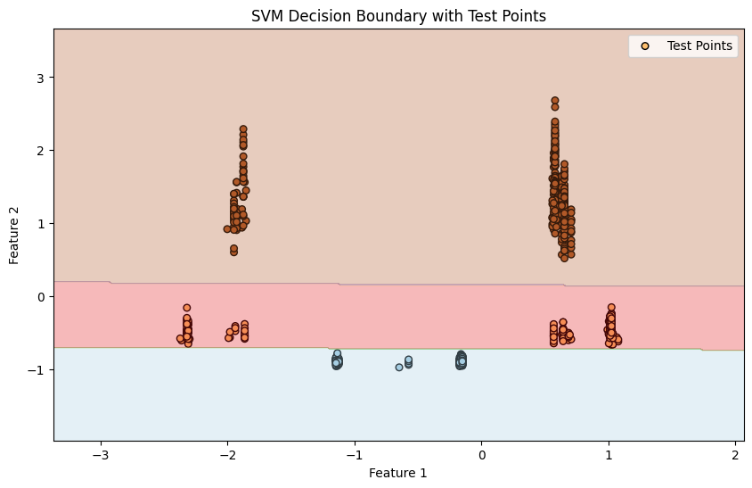

```python
# Train SVM classifier
svm_classifier = SVC(kernel='linear', probability=True)  # Added probability for contour plotting
svm_classifier.fit(train_x, train_y.ravel())

# Predict on the test set
pred_y = svm_classifier.predict(test_x)

# Evaluate the classifier
print("Accuracy:", accuracy_score(test_y, pred_y))
print("Classification Report:")
print(classification_report(test_y, pred_y))

# Plotting decision boundaries
plt.figure(figsize=(10, 6))
plt.scatter(test_x[:, 0], test_x[:, 1], c=test_y.ravel(), s=30, cmap=plt.cm.Paired, edgecolors='k', label='Test Points')

# Plot the decision boundary. For that, we will assign a color to each
# point in the mesh [x_min, x_max]x[y_min, y_max].
x_min, x_max = test_x[:, 0].min() - 1, test_x[:, 0].max() + 1
y_min, y_max = test_x[:, 1].min() - 1, test_x[:, 1].max() + 1
xx, yy = np.meshgrid(np.arange(x_min, x_max, 0.02),
                     np.arange(y_min, y_max, 0.02))

Z = svm_classifier.predict(np.c_[xx.ravel(), yy.ravel()])
Z = Z.reshape(xx.shape)
plt.contourf(xx, yy, Z, alpha=0.3, cmap=plt.cm.Paired)

plt.xlabel('Feature 1')
plt.ylabel('Feature 2')
plt.title('SVM Decision Boundary with Test Points')
plt.legend()
plt.show()
```

- Option 2

```python
def frequency_features_opt2(trainX):
    n_data, n_samples = trainX.shape
    reduced = np.zeros((n_data, 2))

    for i in range(n_data):
        # Perform FFT on each signal
        freq_signal = np.fft.fft(trainX[i, :])
        frequencies = np.fft.fftfreq(n_samples, d=1/n_samples)

        # Get the indices of the two peaks
        # with the highest amplitudes
        indices = np.argsort(np.abs(freq_signal))[-2:]

        reduced[i, :] = np.sort(frequencies[indices])

    return reduced

x = frequency_features_opt2(all_data)
y = [0]*len(normal) + [1]*len(inner) + [2]*len(outer)
y = np.array(y)[:, np.newaxis]

scaler = StandardScaler()
train_X_scaled = scaler.fit_transform(x)
train_x, test_x, train_y, test_y = train_test_split(train_X_scaled,
                                                    y,
                                                    test_size = 0.2,
                                                    random_state = 42)
```

```
Accuracy: 0.912962962962963
Classification Report:
              precision    recall  f1-score   support

           0       1.00      1.00      1.00       390
           1       1.00      0.72      0.84       341
           2       0.79      1.00      0.88       349

    accuracy                           0.91      1080
   macro avg       0.93      0.91      0.91      1080
weighted avg       0.93      0.91      0.91      1080
```

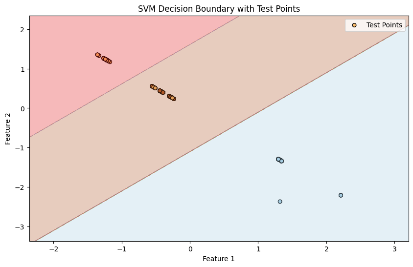

```python
# Train SVM classifier
svm_classifier = SVC(kernel='linear', probability=True)  # Added probability for contour plotting
svm_classifier.fit(train_x, train_y.ravel())

# Predict on the test set
pred_y = svm_classifier.predict(test_x)

# Evaluate the classifier
print("Accuracy:", accuracy_score(test_y, pred_y))
print("Classification Report:")
print(classification_report(test_y, pred_y))

# Plotting decision boundaries
plt.figure(figsize=(10, 6))
plt.scatter(test_x[:, 0], test_x[:, 1], c=test_y.ravel(), s=30, cmap=plt.cm.Paired, edgecolors='k', label='Test Points')

# Plot the decision boundary. For that, we will assign a color to each
# point in the mesh [x_min, x_max]x[y_min, y_max].
x_min, x_max = test_x[:, 0].min() - 1, test_x[:, 0].max() + 1
y_min, y_max = test_x[:, 1].min() - 1, test_x[:, 1].max() + 1
xx, yy = np.meshgrid(np.arange(x_min, x_max, 0.02),
                     np.arange(y_min, y_max, 0.02))

Z = svm_classifier.predict(np.c_[xx.ravel(), yy.ravel()])
Z = Z.reshape(xx.shape)
plt.contourf(xx, yy, Z, alpha=0.3, cmap=plt.cm.Paired)

plt.xlabel('Feature 1')
plt.ylabel('Feature 2')
plt.title('SVM Decision Boundary with Test Points')
plt.legend()
plt.show()
```

### Classification without Feature Selection (ANN)

- Neural networks can deal with high-dimensional, non-linear data

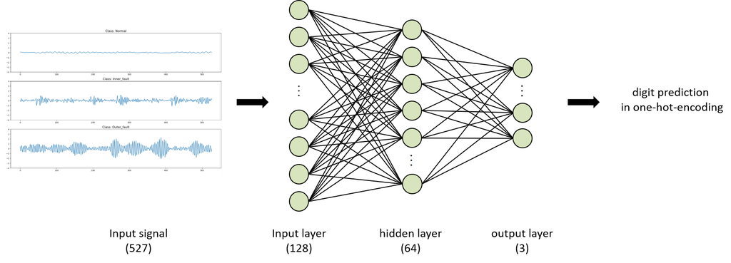

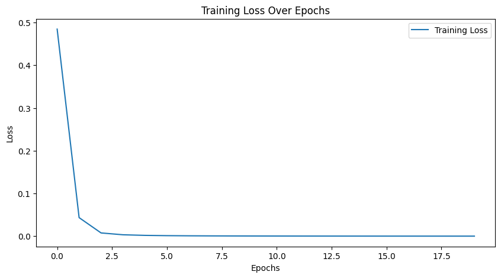

```
Accuracy of the network on the test samples: 100.00%
```

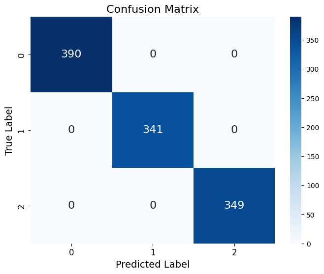

```python
import tensorflow as tf
import numpy as np
from sklearn.model_selection import train_test_split
from sklearn.preprocessing import StandardScaler
from sklearn.metrics import confusion_matrix
import matplotlib.pyplot as plt
import seaborn as sns

# Rename for simplicity
x = all_data
y = np.array([0]*len(normal) + [1]*len(inner) + [2]*len(outer))

scaler = StandardScaler()
train_X_scaled = scaler.fit_transform(x)
train_x, test_x, train_y, test_y = train_test_split(train_X_scaled, y, test_size=0.2, random_state=42)

# Convert to TensorFlow datasets
train_dataset = tf.data.Dataset.from_tensor_slices((train_x, train_y)).shuffle(buffer_size=1024).batch(64)
test_dataset = tf.data.Dataset.from_tensor_slices((test_x, test_y)).batch(64)

# Define the Neural Network Model using Sequential API
model = tf.keras.Sequential([
    tf.keras.layers.Dense(128, activation='relu', input_shape=(527,)),
    tf.keras.layers.Dense(64, activation='relu'),
    tf.keras.layers.Dense(3)  # No activation function as we will use from_logits=True in loss
])

# Compile the model
model.compile(optimizer=tf.keras.optimizers.Adam(learning_rate=0.001),
              loss=tf.keras.losses.SparseCategoricalCrossentropy(from_logits=True),
              metrics=['accuracy'])

# Initialize list to track loss
epoch_losses = []

# Train the model
history = model.fit(train_dataset, epochs=20, verbose=1)

# Store the loss values
epoch_losses = history.history['loss']

# Plot training loss over epochs
plt.figure(figsize=(10, 5))
plt.plot(epoch_losses, label='Training Loss')
plt.xlabel('Epochs')
plt.ylabel('Loss')
plt.title('Training Loss Over Epochs')
plt.legend()
plt.show()

# Evaluate the model on the test set
test_loss, test_accuracy = model.evaluate(test_dataset)
print(f'Accuracy of the network on the test samples: {test_accuracy * 100:.2f}%')

# Predict on the test set and plot confusion matrix
all_predicted = np.argmax(model.predict(test_dataset), axis=-1)
all_labels = np.concatenate([y for x, y in test_dataset], axis=0)

# Confusion Matrix
conf_matrix = confusion_matrix(all_labels, all_predicted)
plt.figure(figsize=(8, 6))
sns.heatmap(conf_matrix, annot=True, fmt='d', cmap='Blues', annot_kws={"size": 16})
plt.xlabel('Predicted Label', fontsize=14)
plt.ylabel('True Label', fontsize=14)
plt.title('Confusion Matrix', fontsize=16)
plt.xticks(fontsize=12)
plt.yticks(fontsize=12)
plt.show()
```

## 2.2. Time Series Dimension Reduction

```
(5400, 2)
```

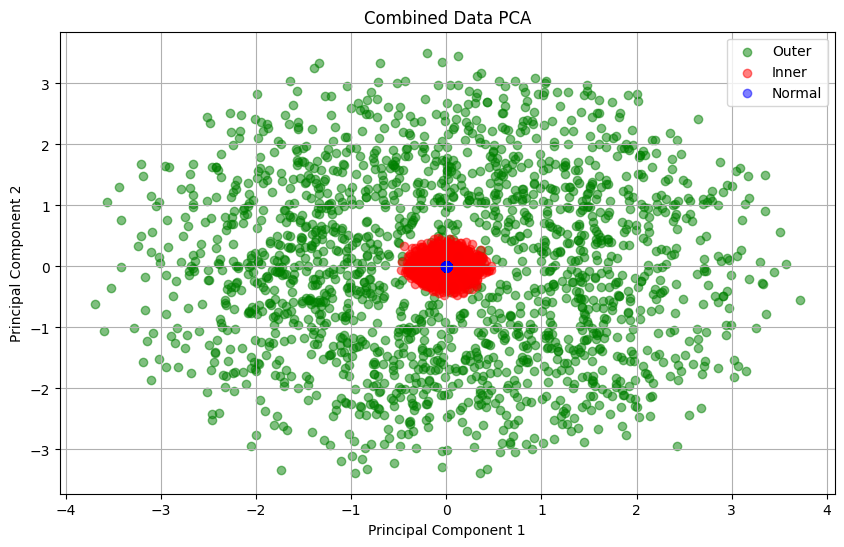

```python
pca = sklearn.decomposition.PCA(n_components=2)

all_data_pca = pca.fit_transform(all_data)
print(all_data_pca.shape)
n_inner = inner.shape[0]
n_normal = normal.shape[0]
n_outer = outer.shape[0]

plt.figure(figsize=(10, 6))

plt.scatter(all_data_pca[n_inner+n_normal:, 0], all_data_pca[n_inner+n_normal:, 1], alpha=0.5, color='green', label='Outer')
plt.scatter(all_data_pca[n_normal:n_inner+n_normal, 0], all_data_pca[n_normal:n_inner+n_normal, 1], alpha=0.5, color='red', label='Inner')
plt.scatter(all_data_pca[:n_normal, 0], all_data_pca[:n_normal, 1], alpha=0.5, color='blue', label='Normal')

plt.title('Combined Data PCA')
plt.xlabel('Principal Component 1')
plt.ylabel('Principal Component 2')
plt.grid(True)
plt.legend()  # Adds a legend to specify which color corresponds to which dataset
plt.show()
```